# Rock Pool Temperature Model

Andy

12/7/2021

# Histograms

First, let’s take a look at some of the data and explore it for correlations.

## Temperature Metrics

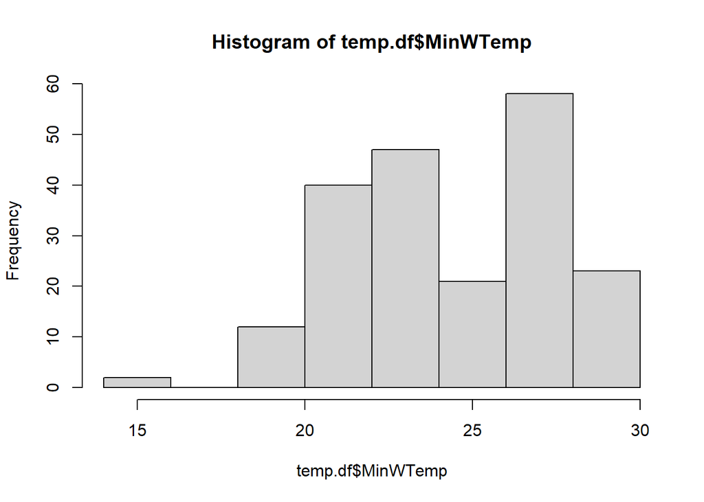

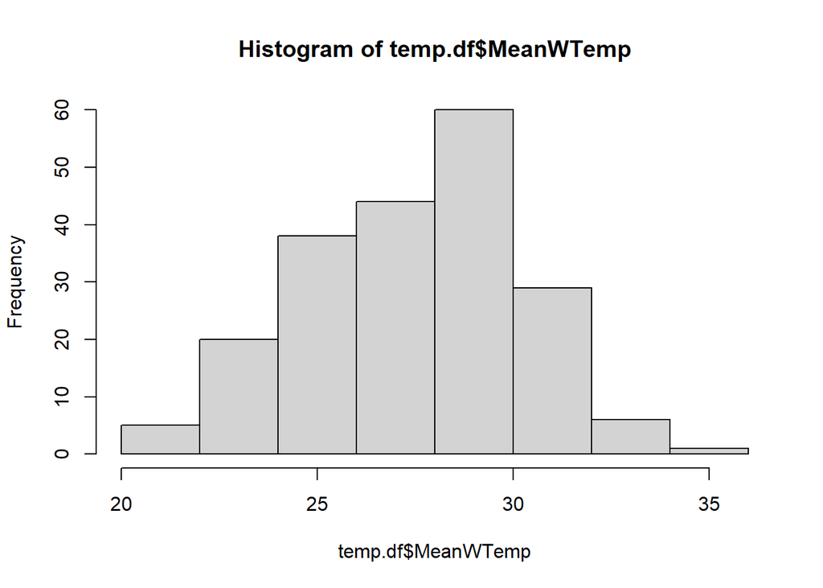

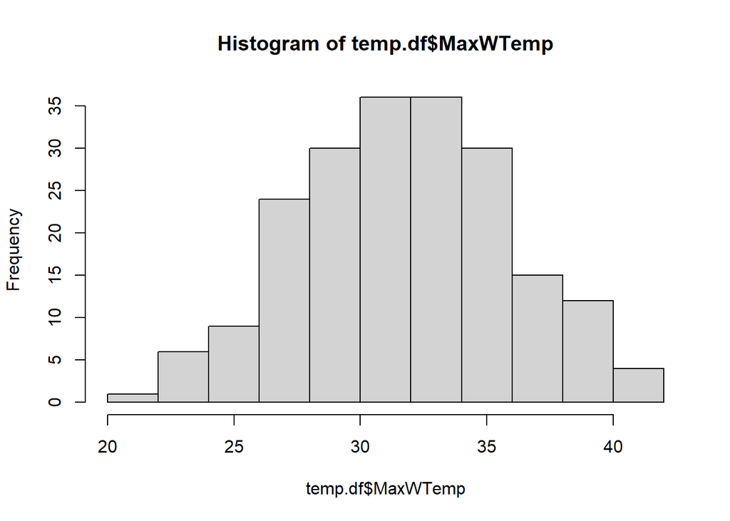

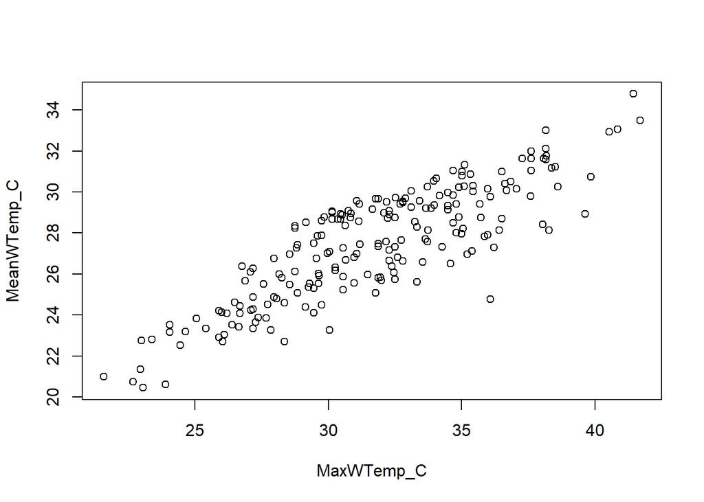

For this analysis, I’m choosing to focus in on maximum water temperature as our dependent variable, because it has a nice and pretty distribution and correlates well with mean water temperature (which is sort of what we’re more interested in here). We could easily use mean temperature as well, but I am hesitant to use it because it does not represent a true daily “mean”, because our data were collected over 8 hour periods and not a full 24 hours.

## Predictor Variables

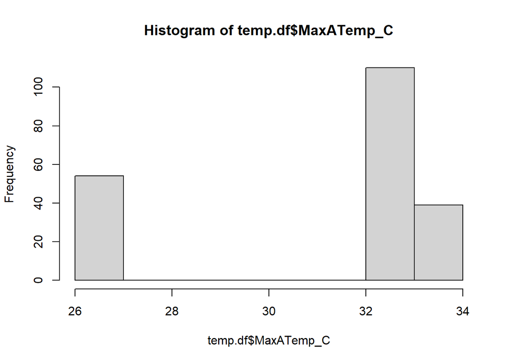

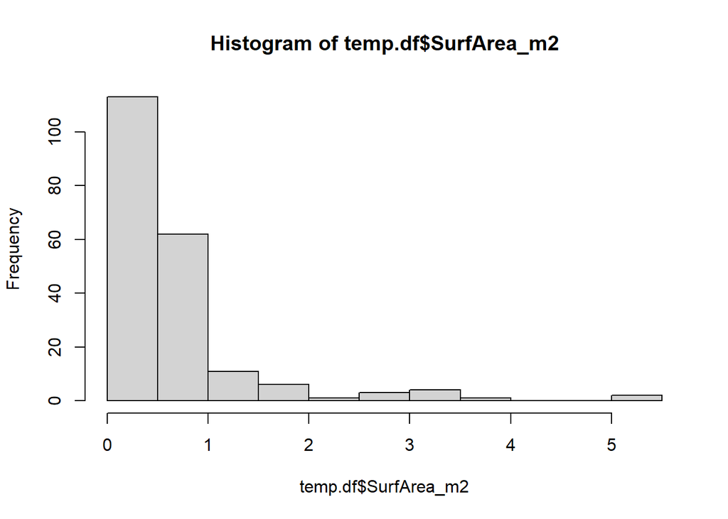

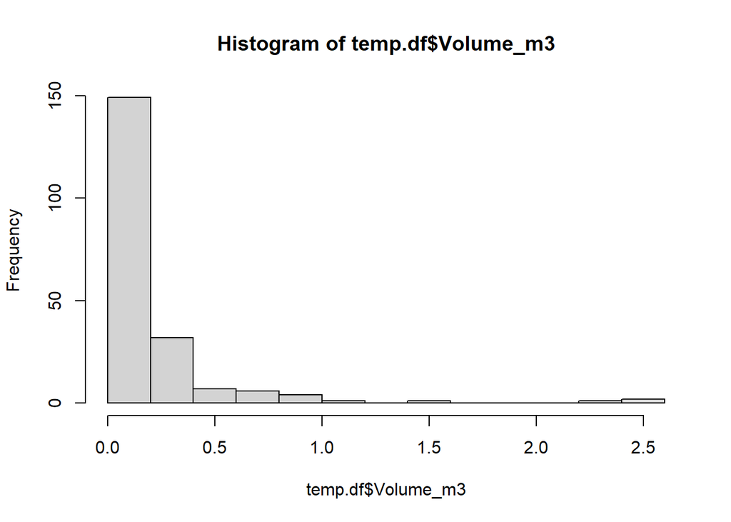

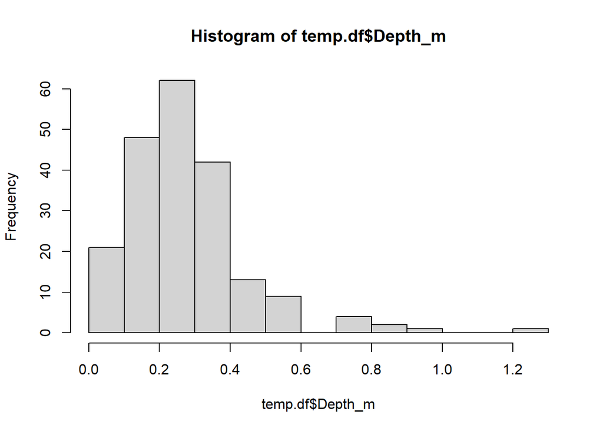

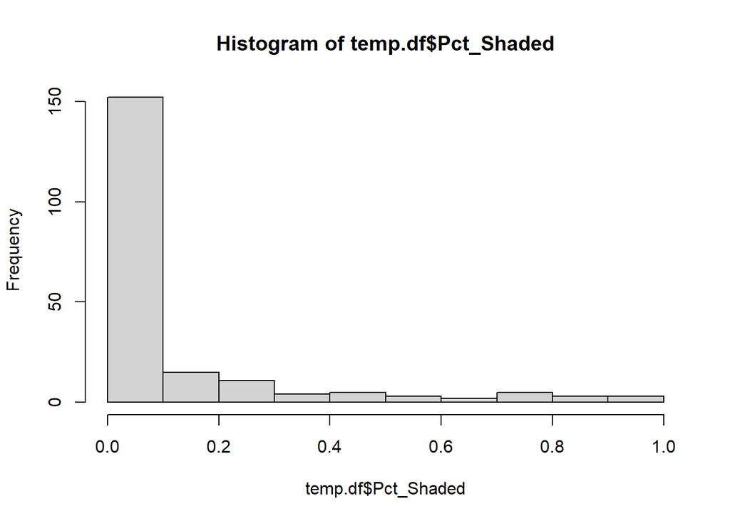

## Applying Transformations

Lots of right-skewing going on, so we’ll do a few transformations. log for Area and Depth, and arcsine for PctShaded since it’s a proportion.

```r
temp.df$logArea <- log(temp.df$SurfArea_cm2)
temp.df$logDepth <- log(temp.df$Depth_cm)
temp.df$arcShade <- asin(sqrt(temp.df$Pct_Shaded))

temp.df$Date <- as.factor(temp.df$Date)
```

# Correlation Plots

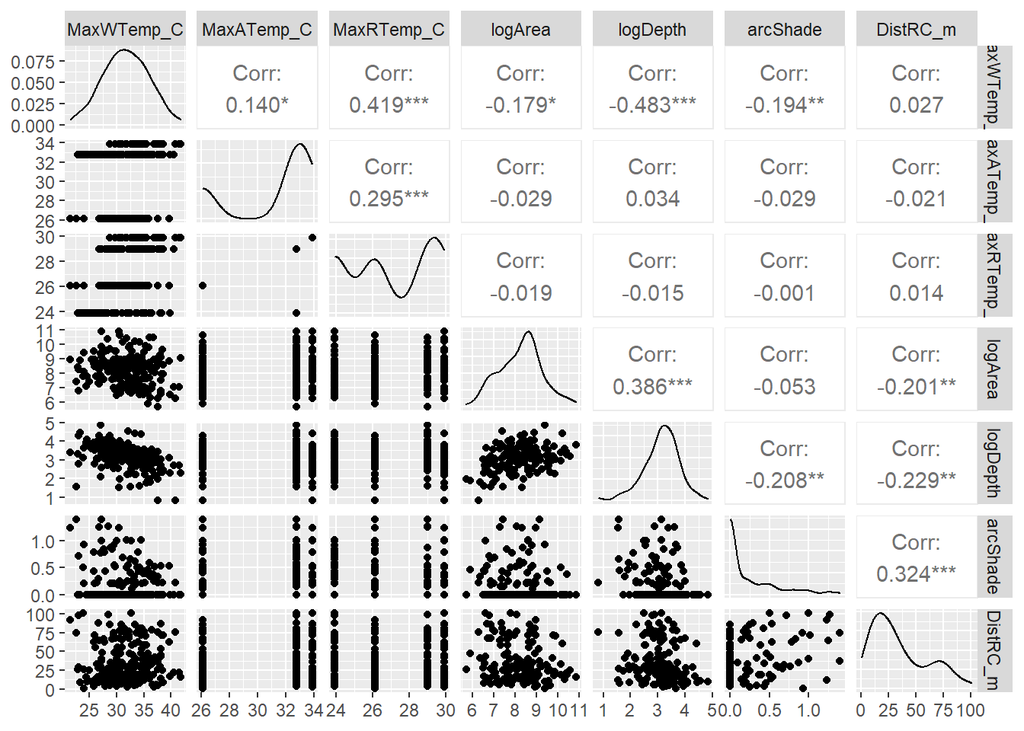

Area and depth look like good predictors, as does maximum air temperature and shade. Oddly, there is also some colinearity going on with some of our predictor variables, too (e.g., area x depth, shade x depth).

# Preliminary Modeling

Let’s try making a basic GLMM using these variables, with area and depth as fixed effects and maximum air temperature as a random effect. We’ll take a stepwise approach to model selection.

Model 2, which excludes area but includes depth, has the lowest AIC. It indicates that depth and shade both negatively impact maximum water temperatures, and there is an interaction - deep, shady pools are probably especially cool. Additionally, maximum air temperature does pull out as a significant random effect.

Curiously, the max air temperature for two of the dates is the same, so I tried it with date as a random effect instead of air temperature, which returned a lower AIC value than model 2. It’s likely that date accounts for more variation in other atmospheric conditions (i.e., temperature variation and mean) than maximum air temperature alone does.

Water temperature data for the river is unavailable through the usual sources at the Westham Gage. Cartersville is available, and using max river temps from there in place of date returns similar AIC values. This might be a better predictive covariate than date and may help capture some of longer term variation in atmospheric conditions.

Continuous, untransformed shade actually provides a lower AIC value than binning it (0-20%, 20-40%, 40-60%, 60-80%, 80-100%) or arcsine transforming it.

Including distance from river channel improves things too, but only marginally, and oddly, the parameter estimates for it aren’t significant.

Some other suggestions: river temperature as a fixed effect instead of a random effect, and pool ID as a random effect.

```
## `nlist()` is deprecated, use `tibble::lst()` instead.
```

| Modnames | model_vars | K | AICc | Delta_AICc | ModelLik | AICcWt | LL | Cum.Wt |
| --- | --- | --- | --- | --- | --- | --- | --- | --- |
| mod21 | MaxWTemp_C + logDepth + Pct_Shaded + MaxRTemp_C + Pool_ID | 7 | 978.5162 | 0.00000 | 1.000000e+00 | 9.969105e-01 | -481.9709 | 0.9969105 |
| mod18 | MaxWTemp_C + logDepth + Pct_Shaded + MaxRTemp_C + Pool_ID | 7 | 990.0699 | 11.55375 | 3.098383e-03 | 3.088811e-03 | -487.7478 | 0.9999993 |
| mod20 | MaxWTemp_C + logDepth + Pct_Shaded + MaxRTemp_C | 9 | 1007.0365 | 28.52029 | 6.410592e-07 | 6.390787e-07 | -494.0519 | 1.0000000 |
| mod17 | MaxWTemp_C + logDepth + Pct_Shaded + DistRC_m + MaxRTemp_C | 10 | 1014.5196 | 36.00340 | 1.520411e-08 | 1.515714e-08 | -496.6808 | 1.0000000 |
| mod16 | MaxWTemp_C + logDepth + Pct_Shaded + MaxRTemp_C | 6 | 1018.0497 | 39.53354 | 2.602566e-09 | 2.594525e-09 | -502.8106 | 1.0000000 |
| mod2 | MaxWTemp_C + logDepth + arcShade + MaxATemp_C | 6 | 1043.2845 | 64.76828 | 8.624740e-15 | 8.598094e-15 | -515.4280 | 1.0000000 |
| mod1 | MaxWTemp_C + logDepth + logArea + arcShade + MaxATemp_C | 10 | 1050.4460 | 71.92985 | 2.402327e-16 | 2.394906e-16 | -514.6501 | 1.0000000 |
| mod19 | MaxWTemp_C + logDepth + Pct_Shaded + Pool_ID | 6 | 1058.6234 | 80.10719 | 4.026668e-18 | 4.014227e-18 | -523.0974 | 1.0000000 |
| mod6 | MaxWTemp_C + logDepth + arcShade | 5 | 1066.8728 | 88.35657 | 6.510493e-20 | 6.490379e-20 | -528.2841 | 1.0000000 |
| mod4 | MaxWTemp_C + logDepth + logArea + arcShade | 9 | 1074.0839 | 95.56769 | 1.769052e-21 | 1.763587e-21 | -527.5756 | 1.0000000 |

[output cut: 11 more lines]

Ultimately, the best model includes Pool ID as a random effect, and river temperature as a fixed effect. Its AIC is 977.9 (nothing else comes particularly close), with a marginal r<sup>2</sup> of 0.52 and a conditional of 0.87. It’s worth noting that Pool ID and lat/long coords (outlined below) are virtually interchangeable here, so we will use Pool ID because it makes the math and interpretation simpler.

## Predicting from the Model

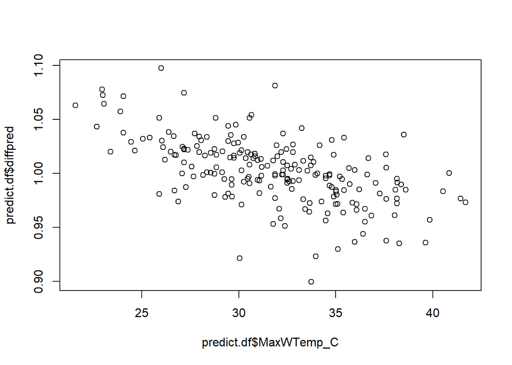

```
## [1] 1.00233
```

Interesting. Some over/underestimating at the tails, but most pools are within +/- 5%.

Million dollar question: can we plot it?

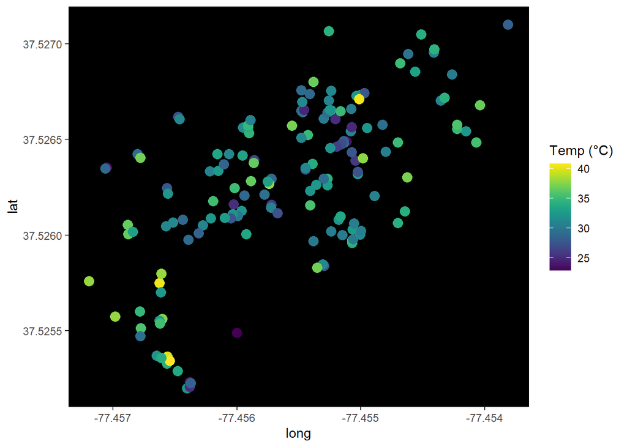

The next step will be to challenge the model (and ourselves) a bit. Can we simulate a day on which the river temperature is 25°C, as an example, and predict temperatures for the whole system? I will need a data set containing pool dimensions and the densiometer data for the full system. Fortunately, I’ve made one.

Awesome. Lastly, let’s convert these temperature estimates into a standardized z-score that measures how relatively “hot” a pool gets.

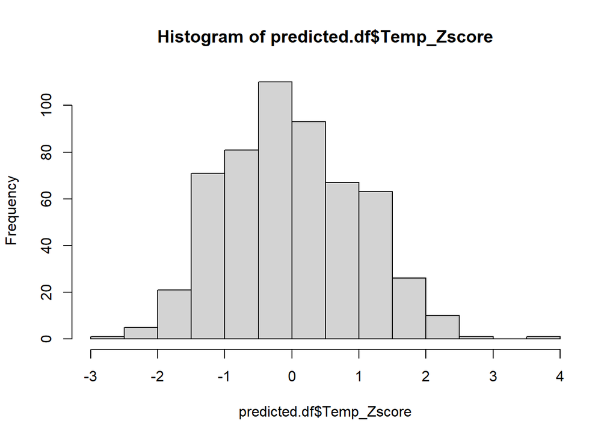

## Spatially Explicit Modeling

This section is deprecated with the realization that Pool ID is as good of a random effect as lat/long. Preserving the code here for posterity.